# Section 2 Homework Solutions

**Exercise 1**.

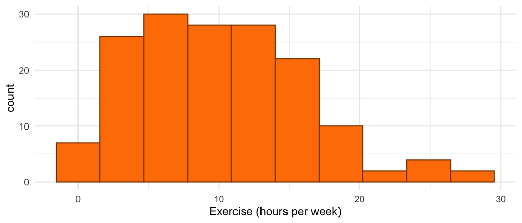

1. right-skewed.
2. approximately 10 hours.
3. approximately 9.5 hours.
4. approximately 5.98 hours.
5. We would expect the mean to be slightly larger than the median if we said the distribution in (a) was right-skewed.
6. We would use the mean to describe the center and the standard deviation to describe the spread if we say there is no extreme skewness or outliers in the distribution of `Exercise`. (Or, we would use the median to describe the center and the IQR to describe the spread if we argue that the distribution is extremely skewed).

**Exercise 2**.

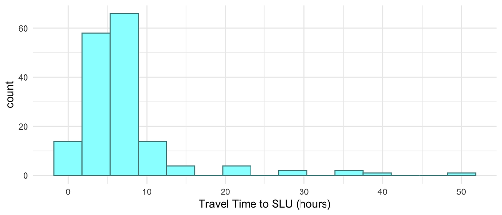

1. right-skewed.
2. We would use the median to describe the center and the IQR to describe the spread of the distribution of `Travel` time because there is extreme right-skewness in the distribution of `Travel`.
3. The pollutant amounts for the the general vehicles should have a larger standard deviation because, if sampling a bunch of different vehicle types (trucks, sedans, etc.), the amount of pollution generated should be **more** spread out/variable than the pollutants generated from a sampling of 50 of the same car model.

**Exercise 3**.

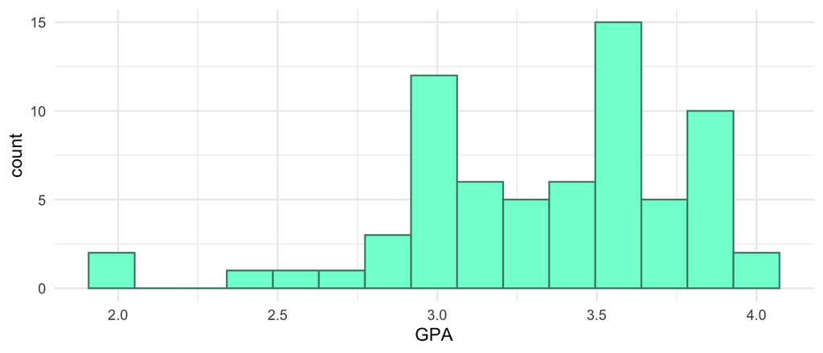

1. left-skewed
2. approximately 3.4 points.
3. approximately 0.6 points.
4. approximately 0.43 points.
5. We would expect the mean GPA to be less than the median GPA because the distribution is left-skewed.
6. Can either say (1) we would use the mean to describe center and standard deviation to describe spread because, though there is some left-skewness in GPA, it is not extreme OR (2) we would use the median to describe center and IQR to describe spread because the distribution of GPA is extremely skewed.
7. Answers will vary but below is one example:

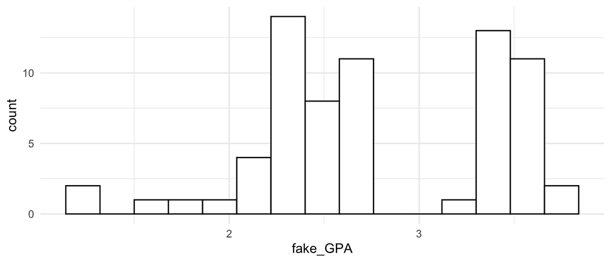

**Exercise 4**.

Lower Fence: 3 - 0.9 = 2.1.

Upper Fence: 3.6 + 0.9 = 4.5

Any value below the lower fence or above the upper fence should be considered an outlier in the boxplot. The lower whisker should extend to the smallest GPA value that is **not** an outlier (2.4 in this case).

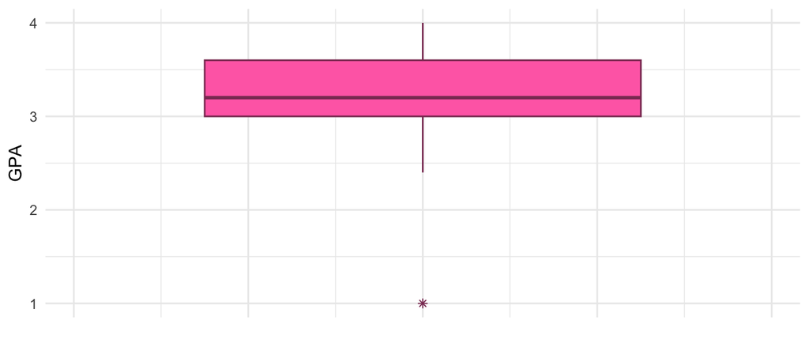

**Exercise 5**.

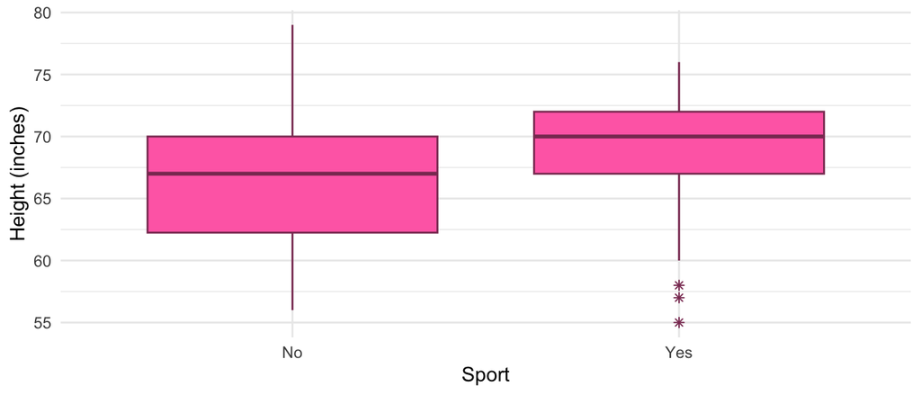

1. Students who do not play a sport: 67 inches.

Students who do play a sport 70 inches.

2. Yes, height and sport do seem associated because the median height for students who do not play a sport is substantially different than the median height for students who do play a sport and there is not a ton of overlap in the distributions of height between the two groups.

**Exercise 6**.

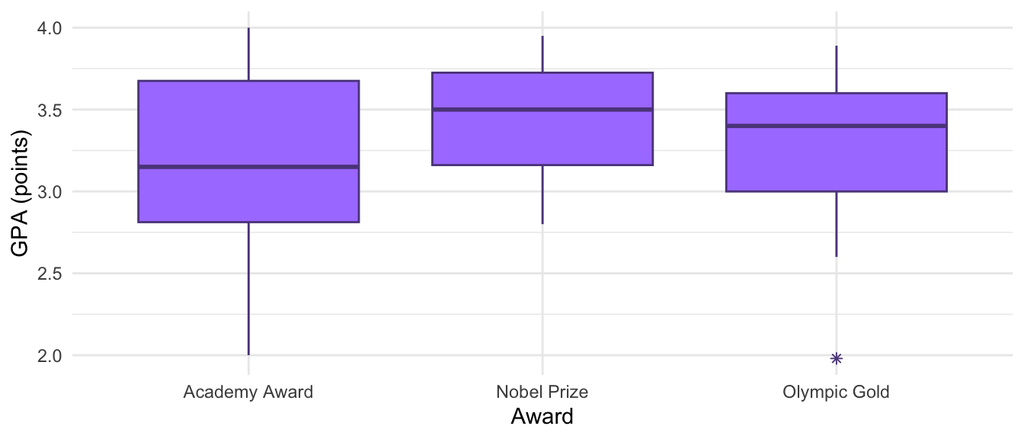

1. Either (1) Yes, GPA and award do seem associated because the median gpas for students for each of the award types are similar there is not a ton of overlap in the distributions of height between the three groups OR
2. No, GPA and award do not seem associated because the median gpas for students for each of the three award types are fairly similar and there is a lot of overlap in the distributions of gpa between the three groups.

I would lean toward (2) for this example.

2. Plot that shows **more** association:

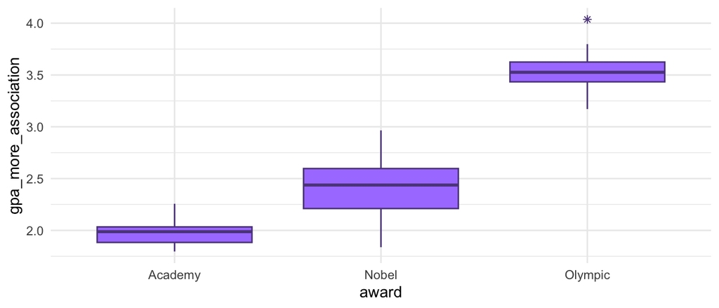

Plot that shows (maybe slightly?) **less** association:

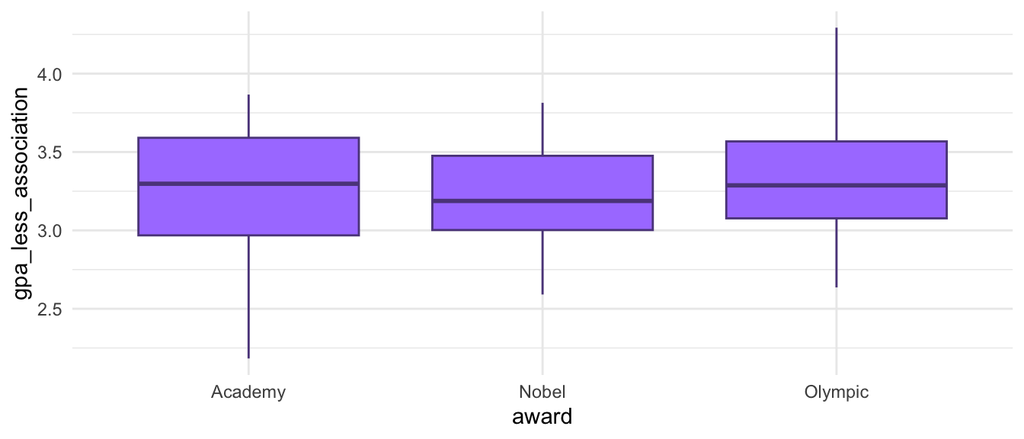

**Exercise 7**.

1. Paired (observations are paired by the specific employee since we are taking two measurements, one before and one after, of each employee).
2. Not Paired (each employee only has one measurement: there is no logical way to “pair” one employee from the mindfulness program group with an employee who did not participate).
3. Not Paired (there is no logical way to pair one house from Canton with a particular house from Potsdam).
4. Paired (observations are paired by athlete since we are taking two measurements from each athlete).

**Exercise 8**.

1. These data are paired because we are measuring assessment 1 and assessment 2 for each student in the class so that it makes logical sense to “pair” each student’s assessments with each other.

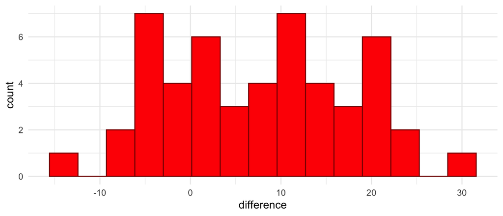

There does look like there is a difference, on average, between mean scores on the two assessments. In particular, it looks like students scored higher on the second assessment, on average, as most of the differences are larger than 0. Therefore, assessment 1 seems to be the more challenging assessment.

3. Any histogram centered around 0 would show no evidence of a difference in average scores on the two assessments:

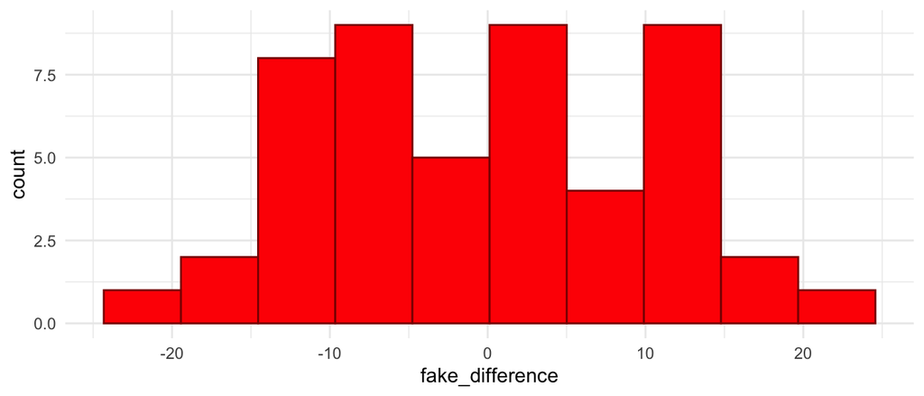

**Exercise 9**.

1. Correlation coefficient of about -0.97.

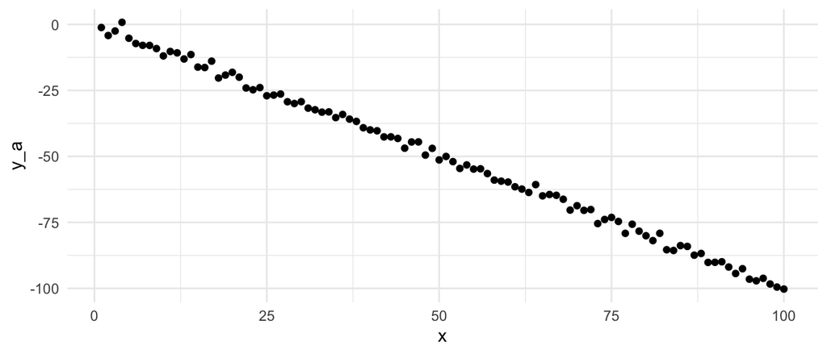

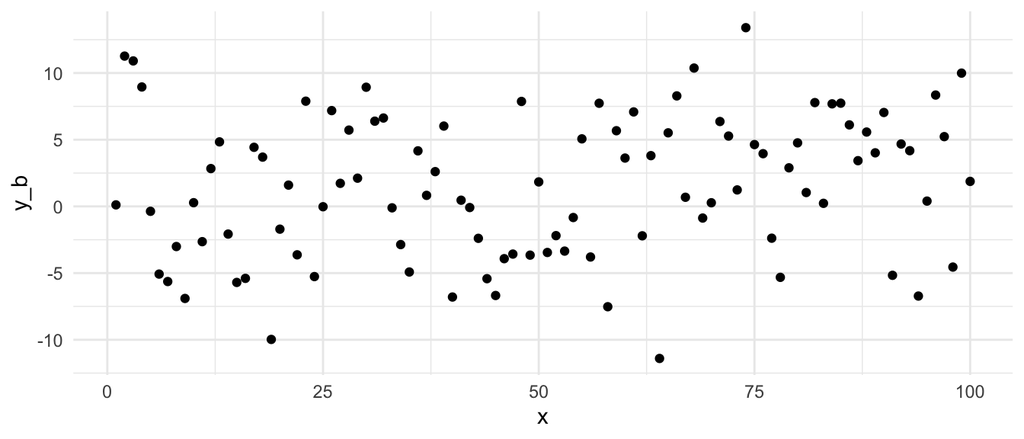

3. Relationship between `y` and `x` **negative**, **weak**, and **linear**.

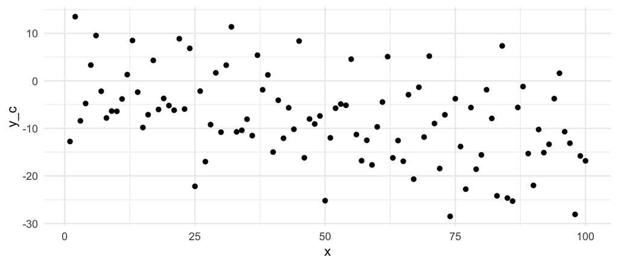

4. Relationship between `y` and `x` **positive**, **strong**, and **linear**.

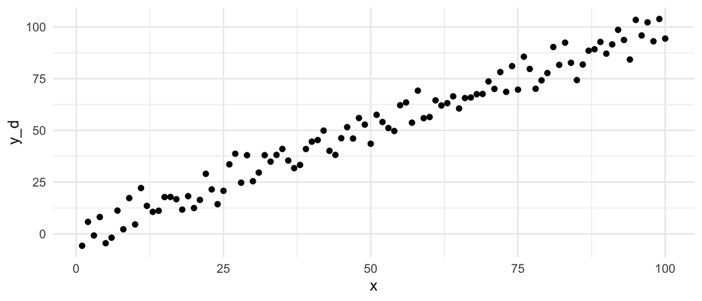

**Exercise 10**.

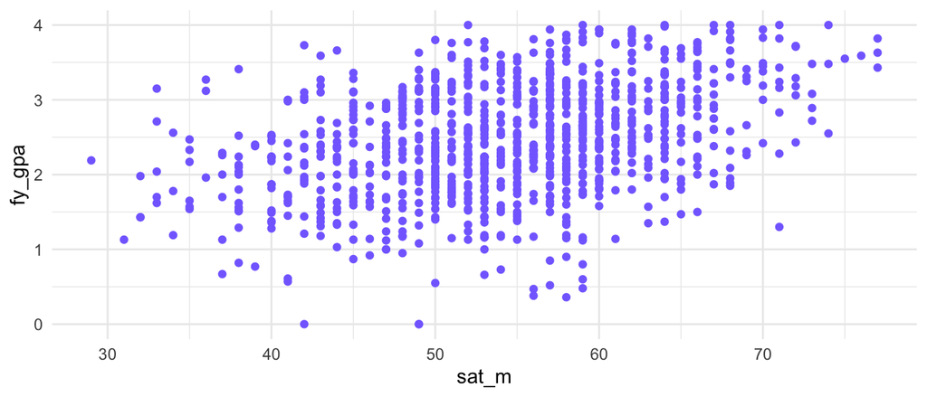

1. The relationship is **linear**, **weak** (or moderate), and **positive**.
2. About `0.3`.

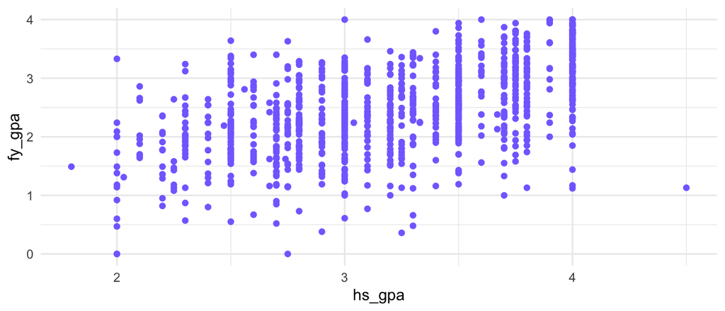

3. The relationship is **linear**, **weak** (or moderate), and **positive**.

**Exercise 11**.

|  | Academy Award | Nobel Prize | Olympic Gold |
| --- | --- | --- | --- |
| **No** | 15 | 29 | 15 |
| **Yes** | 6 | 22 | 76 |

1. Of those that do not play a sport, what proportion would want to win an Olympic Medal? 0.254

Of those that do not play a sport, what proportion would want to win an Academy Award? 0.254

Of those that do not play a sport, what proportion would want to win a Nobel Prize? 0.492

2. Of those that play a sport, what proportion would want to win an Olympic Medal? Of those that do not play a sport, what proportion would want to win an Olympic Medal? 0.731

Of those that play a sport, what proportion would want to win an Academy Award? 0.058

Of those that play a sport, what proportion would want to win a Nobel Prize? 0.212

3. Row proportions.

A stacked bar chart of the proportions that were calculated is given below.

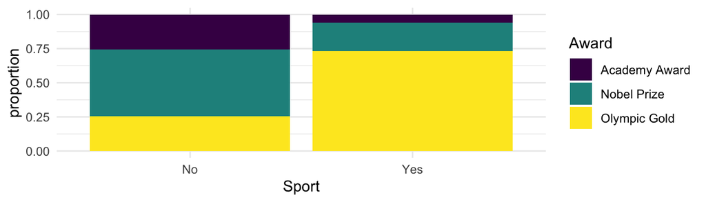

4. Yes, it looks like the variables are associated because the proportion of students who play a sport that responded they would prefer the Olympic medal is much higher than the proportion of students who do not play a sport that responded they would prefer the Olympic medal. We can see this in the bar plot because the distribution of `No` sport students is substantially different than the distirbution of `Yes` sport students

**Exercise 12**.

|  | female | male |
| --- | --- | --- |
| **air force** | 64200 | 267286 |
| **army** | 74845 | 481004 |
| **marine corps** | 13200 | 189766 |
| **navy** | 50473 | 273819 |

1. Of the sampled people in the air force, what proportion are female? 0.194

Of the sampled people in the army, what proportion are female? 0.135

Of the sampled people in the marine corps, what proportion are female? 0.065

Of the sampled people in the navy, what proportion are female? 0.156

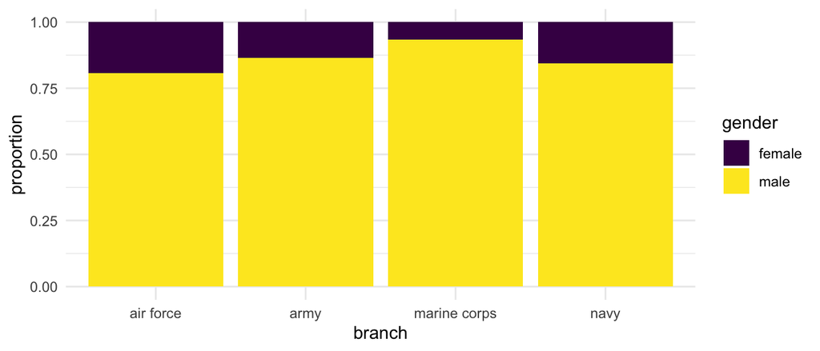

2. Can either say (1) yes, they do seem associated because the proportion of female members in some branches (like the air force and navy) is much higher than the proportion of female service members in other branches (like the marine corps). The bar plot shows the differing proportions of female service members within each branch OR
2. no, they do not seem associated because the proportion of female members is approximately the same in each branch. We see this in the stacked bar plot, as the distribution of `gender` is roughly the same for each `branch`.

I would lean toward (1) for this example.

3. Answers will vary but here is one example:

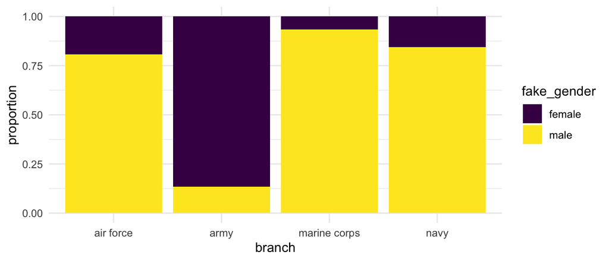

**Exercise 13**.

|  | 10 or less | more than 10 |
| --- | --- | --- |
| **1B** | 10 | 41 |
| **2B** | 33 | 23 |
| **3B** | 26 | 29 |
| **SS** | 22 | 21 |

1. `position`: 4 levels and whether or not the player hit `more than 10 homeruns`: 2 levels.
2. 41 / 51 = 80.4%: row percent.
3. 23 / 56 = 41.1%: row percent.

Below is a stacked bar plot of the data.

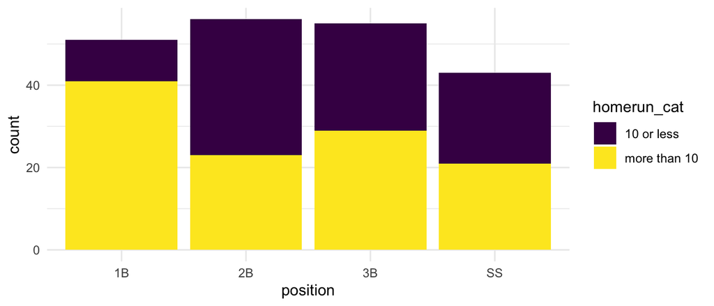

4. Yes, the variables do seem like they are associated. A higher proportion of the first base `1B` players hit more than 10 homeruns compared to the other three positions so the distribution for `1B` players looks substantially different than the distributions of the other three players.
5. Answers can vary but below is one example of a stacked bar plot that shows **less** of an association than our observed data.

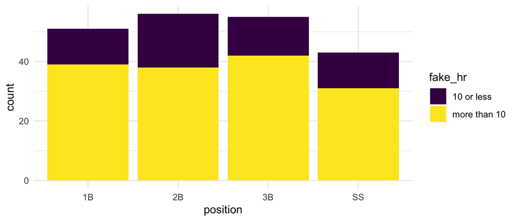

**Exercise 14**.

1. Histogram or Boxplot.
2. Scatterplot.
3. Side-by-side Boxplot.
4. Barplot.
5. Stacked Barplot.
6. Side-by-side Boxplot.